# CDA Homework 2

Joshua Ingram

September 10, 2019

Questions:

1.1: In the following examples, identify the natural response variable and the explanatory variables.

1. Response: Attitude toward gun control Explanatory: gender, mather’s education
2. Response: Heart Disease Explanatory: Blood Pressure, Cholesterol Level
3. Response: Vote for President Explanatory: Race, Religion, Annual Income

1.2 Which scale of measurement is most appropriate for the following variables - nominal or ordinal?

1. nominal
2. ordinal
3. ordinal
4. nominal
5. nominal
6. ordinal

1.3 Each of the 100 multiple-choice questions on an exam has four possible answers but one correct response. For each question, a student randomly selects one response as the answer.

1. Binomial Distribution
2. It would be surprising if a student recieved 50 correct responses, as the mean is 25 (.25 * 100 (pi x n)) and the standard deviation is 4.33 (sqrt(n(pi)(1-pi))). For a student to get 50 correct responses after guessing randomly, it would be more than 3 standard deviations away from the mean, which is extremely unlikely based upon the empirical rule.

```r
dbinom(50, 100, .25)
```

```
## [1] 4.507311e-08
```

```r
pbinom(49, 100, .25)
```

```
## [1] 0.9999999
```

```r
1 - pbinom(49, 100, .25)
```

```
## [1] 6.638502e-08
```

1.4 In a particular city, the population proportion PI supports an increase in the minimum wage. For a random sample of size 2, let Y = number who support an increase.

```r
y0 <- dbinom(0, 2, .50)
print(paste('P(Y=0) =', y0))
```

```
## [1] "P(Y=0) = 0.25"
```

```r
y1 <- dbinom(1, 2, .50)
print(paste('P(Y=1) =', y1))
```

```
## [1] "P(Y=1) = 0.5"
```

```r
y2 <- dbinom(2, 2, .50)
print(paste('P(Y=2) =', y2))
```

```
## [1] "P(Y=2) = 0.25"
```

```r
mean.dist <- .50 * 2
sd.dist <- sqrt(2*.5*(1-.5))
print(paste("The mean of the distribution is", mean.dist, "and the standard deviation is", sd.dist))
```

```
## [1] "The mean of the distribution is 1 and the standard deviation is 0.707106781186548"
```

Distribution:

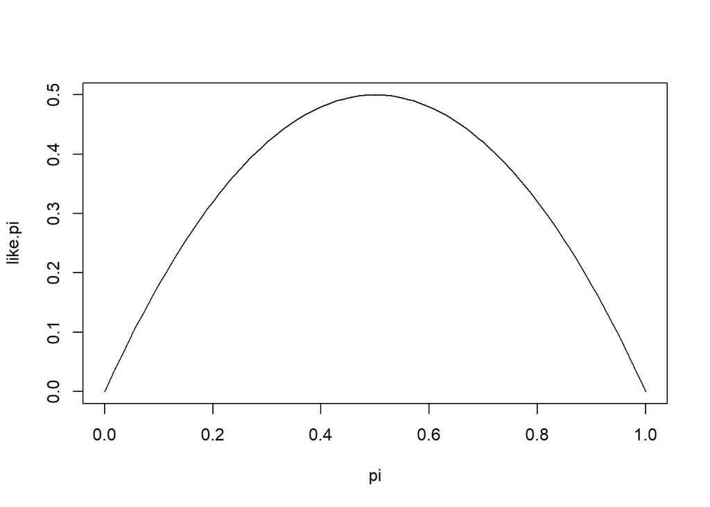

```r
pi = seq(0,1,0.01)
like.pi = dbinom(1, 2, pi)
plot(pi, like.pi, type="l")
```

the ML estimate pi-hat is .50 as the ML, as seen on the graph, is at pi =.50 (where ML is maximum)… also y/n = .50

1.6 Genotypes AA< Aa, and aa occur with probabilities (PI_1, PI_2, PI_3). For n = 3 independent observations, the observed frequencies are (y_1, y_2, y_3).

1. when obtaining the 3 observed frequencies over n=3 observations, we can deduce the value of y_3 from knowing that y_1 + y_2 + y_3 = n, thus y_3 = n - y_1 - y_2. So if we know n, y_1, and y_2, then we know y_3.
2. possible outcomes: (AA,AA,AA) (AA,AA,Aa) (AA,AA,aa) (AA,Aa,Aa) (AA,Aa,aa) (AA,aa,aa) (Aa,Aa,Aa) (Aa,Aa,aa) (Aa,aa,aa) (aa,aa,aa)

```r
grid = expand.grid(0:3,0:3,0:3)
index = rowSums(grid)
index1 = index == 3
grid3 = grid[index1,]
multinomdist <- apply(grid3,1,dmultinom,size=3,prob=c(.25,.50,.25))
multinomdist1 <- cbind(grid3, multinomdist)
multinomdist1
```

```
##    Var1 Var2 Var3 multinomdist
## 4     3    0    0     0.015625
## 7     2    1    0     0.093750
## 10    1    2    0     0.187500
## 13    0    3    0     0.125000
## 19    2    0    1     0.046875
## 22    1    1    1     0.187500
## 25    0    2    1     0.187500
## 34    1    0    2     0.046875
## 37    0    1    2     0.093750
## 49    0    0    3     0.015625
```

```r
print("Checking to see if probabilities add up to 1")
```

```
## [1] "Checking to see if probabilities add up to 1"
```

```r
sum(multinomdist1[,4])
```

```
## [1] 1
```

3. The probability distribution would be a Binomial Distribution for y_1 alone.

1.7

```r
dbinom(0, 6, (5/6))
```

```
## [1] 2.143347e-05
```